# Join ROMS Fluxes

Owen Liu

12/21/2020

# Purpose

Join ROMS data to Atlantis. These need to be tranlsated from the ROMS grid structure into the Atlantis polygon format by calculating fluxes across polygon faces.

For static variables like salinity and temperature, these need to be summarized across the ROMS points within in each Atlantis polygon.

This is all in 3 dimensions, i.e., we need to match the two grids together by x, y, and z coordinates.

AFAIK, ROMS grids have consistent x and y coordinates, but the z for each timestep can vary. To try to reduce computing time, we will only match the x and y coordinates between Atlantis and ROMS once, while allowing for ROMS depth (and, by extension, the matched ROMS/Atlantis depths) to vary.

# Import data

Import an example ROMS file and the California Current Atlantis polygons From Mike Jacox 12/28/20 - *The larger one is a sample of what the ROMS output looks like, with all variables (only physics in this example, no biogeochemistry). The other file has the depths that go with the 3D variables. At this stage I think you’ll be most interested in temp, salinity, and currents. Variable names (and associated dimensions) for those are: temp (rho) salt (rho) u (u) v (v) w (w)*

```r
romsfile <- here::here('data','roms','wc12_ccsra31_his_month_avg_1981_2010_Jan.nc')
roms <- tidync(romsfile)
romsfile2 <- here::here('data','roms','ccsra_depths_sample.nc')
roms2 <- tidync(romsfile2)
```

For sanity, here are the ROMS variables and grids from the main netCDF

```r
roms_vars <- hyper_grids(roms) %>% # all available grids in the ROMS ncdf
  pluck("grid") %>% # for each grid, pull out all the variables asssociated with that grid and make a reference table
  purrr::map_df(function(x){
    roms %>% activate(x) %>% hyper_vars() %>%
      mutate(grd=x)
  })
# first 10 rows
roms_vars %>% slice(1:10) %>% knitr::kable()
```

| id | name | type | ndims | natts | dim_coord | grd |
| --- | --- | --- | --- | --- | --- | --- |
| 133 | salt_obc | NC_DOUBLE | 5 | 3 | FALSE | D15,D5,D11,D14,D0 |
| 143 | temp_obc | NC_DOUBLE | 5 | 4 | FALSE | D15,D5,D11,D14,D0 |
| 152 | u_obc | NC_DOUBLE | 5 | 4 | FALSE | D15,D5,D11,D14,D0 |
| 157 | v_obc | NC_DOUBLE | 5 | 4 | FALSE | D15,D5,D11,D14,D0 |
| 154 | ubar_obc | NC_DOUBLE | 4 | 4 | FALSE | D15,D11,D14,D0 |
| 159 | vbar_obc | NC_DOUBLE | 4 | 4 | FALSE | D15,D11,D14,D0 |
| 163 | zeta_obc | NC_DOUBLE | 4 | 4 | FALSE | D15,D11,D14,D0 |
| 0 | AKk | NC_DOUBLE | 4 | 6 | FALSE | D3,D2,D1,D0 |
| 1 | AKp | NC_DOUBLE | 4 | 6 | FALSE | D3,D2,D1,D0 |
| 2 | AKs | NC_DOUBLE | 4 | 5 | FALSE | D3,D2,D1,D0 |

and if we want, for the depths ncdf

```r
roms2_vars <- hyper_grids(roms2) %>% # all available grids in the ROMS ncdf
  pluck("grid") %>% # for each grid, pull out all the variables asssociated with that grid and make a reference table
  purrr::map_df(function(x){
    roms2 %>% activate(x) %>% hyper_vars() %>%
      mutate(grd=x)
  })
```

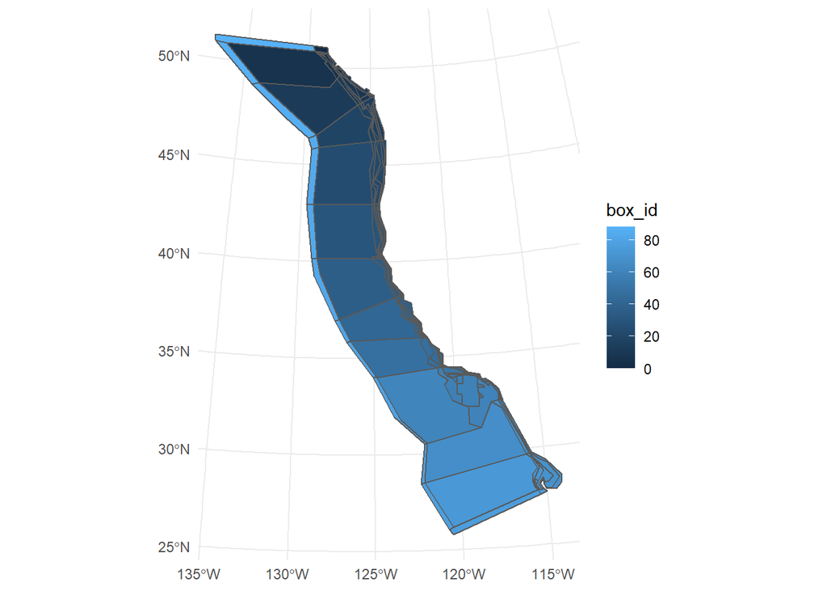

```r
# Boundary geometry file from Atlantis
atlantis_bgm <- read_bgm(here('data','atlantis','CalCurrentV3_utm.bgm'))
#Atlantis geometry as an sf shapefile
atlantis_sf <- atlantis_bgm %>% box_sf()
ggplot(atlantis_sf)+
  geom_sf(aes(fill=box_id))+
  theme_minimal()
```

```r
# plot(atlantis_sf['box_id'])
glimpse(atlantis_sf)
```

```
## Rows: 89
## Columns: 14
## $ label       <chr> "Box0", "Box1", "Box2", "Box3", "Box4", "Box5", "Box6", "B~
## $ nconn       <int> 5, 8, 12, 9, 8, 9, 8, 4, 10, 8, 6, 5, 5, 3, 5, 12, 13, 12,~
## $ botz        <dbl> -104.43, -23.61, -75.58, -199.98, -421.75, -1023.04, -2400~
## $ area        <dbl> 2322414701, 919119184, 1543222863, 1659492667, 536719857, ~
## $ vertmix     <dbl> 1e-06, 1e-06, 1e-06, 1e-06, 1e-06, 1e-06, 1e-06, 1e-06, 1e~
## $ horizmix    <dbl> 1, 1, 1, 1, 1, 1, 1, 1, 1, 1, 1, 1, 1, 1, 1, 1, 1, 1, 1, 1~
## $ relax_tol   <int> 0, 0, 0, 0, 0, 0, 0, 0, 0, 0, 0, 0, 0, 0, 0, 0, 0, 0, 0, 0~
## $ insideX     <dbl> -214154.323, -128301.232, -151332.789, -170241.597, -17350~
## $ insideY     <dbl> 3220952, 3137345, 3151116, 3165538, 3156726, 3141174, 3124~
## $ .bx0        <dbl> 0, 1, 2, 3, 4, 5, 6, 7, 8, 9, 10, 11, 12, 13, 14, 15, 16, ~
## $ relax_tol.1 <int> NA, NA, NA, NA, NA, NA, NA, NA, NA, NA, NA, NA, NA, NA, NA~
## $ boundary    <lgl> TRUE, FALSE, FALSE, FALSE, FALSE, FALSE, FALSE, FALSE, FAL~
## $ geometry    <POLYGON [m]> POLYGON ((-171362.7 3199943..., POLYGON ((-171362.~
## $ box_id      <int> 0, 1, 2, 3, 4, 5, 6, 7, 8, 9, 10, 11, 12, 13, 14, 15, 16, ~
```

# ROMS grids

Find and extract the rho-points, u and v points, and cell depths for our ROMS grid. We add indexing numbers to match tables later. Graphic [here](https://www.myroms.org/wiki/Grid_Generation)

- $\rho$ has $(\xi,\eta)$ dimensions 186 and 181, respectively
- $u$ has $(\xi,\eta)$ dimensions 185 and 181, respectively
- $v$ has $(\xi,\eta)$ dimensions 186 and 180, respectively

So, the closest rho points to u(x,y) are rho(x,y) and rho(x+1,y) The closest rho points to v(x,y) are rho(x,y) and rho(x,y+1)

```r
# cell lat/lons and depths from ROMS
rho_grd <- roms_vars %>% filter(name=="h") %>% pluck('grd')
roms_rho <- roms %>% activate(rho_grd) %>% hyper_tibble() %>%
  select(lat_rho,lon_rho,xi_rho,eta_rho,h)

# s_rho
s_rho_grd <- roms_vars %>% filter(name=="s_rho") %>% pluck('grd')
s_rho <- roms %>% activate(s_rho_grd) %>% hyper_tibble()
## Cs_r is the S-coord stretching (length is num layers from -1 to 0 describing what portion of the w.c. each layer spans)
## We pull the Cs_r values from the roms ncdf
## one Cs_r value per s-coordinate
Cs_r <- s_rho %>% pluck('Cs_r')

# h and Cs_r
h_grd <- roms_vars %>% filter(name=="h") %>% pluck('grd')
h <- roms %>% activate(h_grd) %>% hyper_tibble() %>% select(xi_rho,eta_rho,h)

# find appropriate ROMS ncdf grid for the rho points
latlon_rhogrd <- roms_vars %>% filter(name=="lat_rho") %>% pluck('grd')
# pull the lon/lats
roms_rho <- roms %>% activate(latlon_rhogrd) %>% hyper_tibble() %>% select(lon_rho,lat_rho,xi_rho,eta_rho) %>%
  mutate(rhoidx=row_number()) # add index
```

The “rho” points depths are the vertical center of the cells (or layers). The interfaces are at the “w” points. Hence there are N rho-points and N+1 w-points. The bottom of the bottom-most layer is z=-h, and therefore the z-center of the bottom-most layer is above this. Likewise, the top of the top-most layer is z=0 (actually z=zeta) so the z-center is below this. See [image](https://www.myroms.org/wiki/images/4/41/vertical_grid.png)

```r
#s_w?
s_w_grd <- roms_vars %>% filter(name=="s_w") %>% pluck('grd')
s_w <- roms %>% activate(s_w_grd) %>% hyper_tibble()
Cs_w <- s_w %>% pluck('Cs_w')
```

```r
# u and v grids from ROMS data
latlon_ugrd <-roms_vars %>% filter(name=="lat_u") %>% pluck('grd')
latlon_vgrd <-roms_vars %>% filter(name=="lat_v") %>% pluck('grd')

# pull the lon/lats
roms_u <- roms %>% activate(latlon_ugrd) %>% hyper_tibble() %>% select(lon_u,lat_u,xi_u,eta_u)
roms_v <- roms %>% activate(latlon_vgrd) %>% hyper_tibble() %>% select(lon_v,lat_v,xi_v,eta_v)
```

For distance calculations and spatial mapping, we want to convert lat/lon coordinates to the same coordinate reference system that is used to represent the Atlantis boxes. We do this using the `sf` package, adding the converted XY coordinates to the indices we just created.

```r
append_xy_coords <- function(lonlatdat,xyproj=atlantis_bgm$extra$projection,lon_col="lon_rho",lat_col="lat_rho"){
  lonlatdat %>%
    st_as_sf(coords=c(lon_col,lat_col),crs=4326,remove=F) %>%  # convert to spatial object
    st_transform(xyproj) %>%  # convert to Atlantis coords
    mutate(x = st_coordinates(.)[,1],
           y = st_coordinates(.)[,2]) # grab x and y coordinates and add them as attributes
}

rhoxy<- append_xy_coords(roms_rho,lon_col="lon_rho",lat_col="lat_rho") %>% mutate(rhoidx=row_number())
uxy <- append_xy_coords(roms_u,lon_col="lon_u",lat_col="lat_u")%>% mutate(uidx=row_number())
vxy <- append_xy_coords(roms_v,lon_col="lon_v",lat_col="lat_v")%>% mutate(vidx=row_number())
```

# Faces and Angles

Extract faces of each polygon from Atlantis and organize them

```r
# information about each face, including its angular coords, and which boxes are to its left and right
faces <- atlantis_bgm$faces %>% select(-label)
glimpse(faces)
```

```
## Rows: 388
## Columns: 6
## $ cosine <dbl> 0.99625614, 0.32938359, 0.08596021, 0.99633591, 0.69154912, 0.0~
## $ sine   <dbl> 0.08645063, 0.94419619, 0.99629857, 0.08552628, 0.72232944, 0.9~
## $ left   <int> 60, 60, 59, 60, 60, 59, 60, 60, 60, 59, 61, 59, 59, 59, 59, 59,~
## $ right  <int> 59, 56, 56, 59, 57, 57, 59, 59, 61, 61, 58, 58, 58, 58, 58, 58,~
## $ length <dbl> 37982.782, 39655.290, 17456.791, 31378.605, 37961.750, 13094.00~
## $ .fx0   <dbl> 0, 1, 2, 3, 4, 5, 6, 7, 8, 9, 10, 11, 12, 13, 14, 15, 16, 17, 1~
```

```r
faces_sf <- atlantis_bgm %>% face_sf() %>%
  mutate(label = 0:(length(label)-1)) %>% # creates a new index 'face_id' starting from 0 and increasing, as the 'label' column produced by rbgm::face_sf() is incorrect (tested in R 4.0.4)
  # join attribute data
  left_join(faces,by=c('label'='.fx0')) %>%
  rename(.fx0=label)
```

The `faces` table has the sine and cosine of each face, its length in meters, and which Atlantis box is to its left and right

# Match ROMS to Faces

Find all the rho, u, and v points within a buffer around each face, and build an index. For this step, we assume that the linear unit of the distance calculation is meters. We build a rounded buffer of **10 km** (`dist=10000`) around each face and then find all rho, u, and v points that fall within that buffer. If the Atlantis spatial representation is not in meters, adjust the `dist` argument accordingly.

```r
faces_buffer <- st_buffer(faces_sf,dist=10000)
# join rho points
faces_rho_join <- faces_buffer %>% st_join(rhoxy)
# join u points
faces_u_join <- faces_buffer %>% st_join(uxy)
# join v points
faces_v_join <- faces_buffer %>% st_join(vxy)
```

Example map of what this means spatially

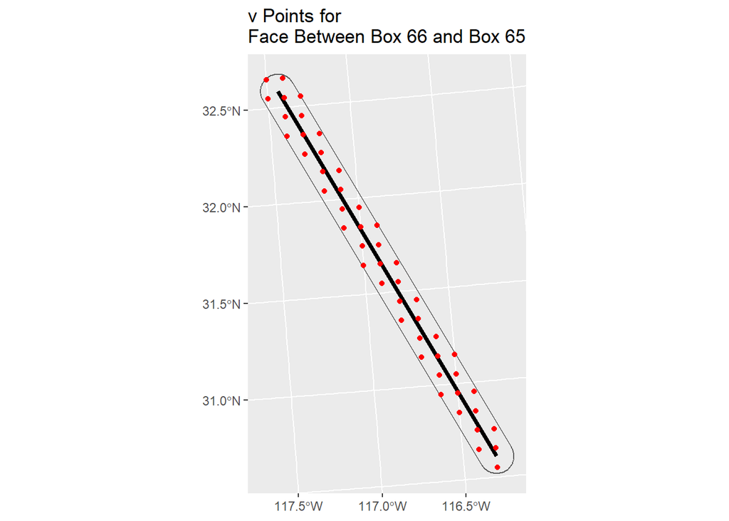

```r
set.seed(413)
tfaceidx <- sample(faces_v_join$.fx0,1)
tvidx <- faces_v_join %>% filter(.fx0==tfaceidx) %>% pluck('vidx')
tbuff <- faces_v_join %>%
  filter(.fx0==tfaceidx) %>%
  sample_n(1) # example face
tface <- faces_sf %>%
  filter(.fx0==unique(tbuff$.fx0))
tbbox <- st_bbox(tbuff)
tv <- vxy %>%
  filter(vidx %in% tvidx)
ggplot()+
  # geom_sf(data=atlantis_sf,fill="blue")+
  geom_sf(data=tbuff,fill=NA)+
  geom_sf(data=tface,col='black',size=1.5)+
  geom_sf(data=tv,col='red')+
  coord_sf(xlim=c(tbbox[1],tbbox[3]),ylim=c(tbbox[2],tbbox[4]))+
  labs(title=paste("v Points for\nFace Between Box",unique(tbuff$left),"and Box",unique(tbuff$right)))
```

```r
rm(tbuff,tbbox,tface,tvidx,tfaceidx)
```

# Match ROMS to Boxes

In order to match depth layers between ROMS and Atlantis, we want to determine which Atlantis box each ROMS grid point is in (if any).

```r
boxes_rho_join <- atlantis_sf %>% st_join(rhoxy)
# join u points
boxes_u_join <- atlantis_sf %>% st_join(uxy) %>% select(.bx0,uidx) %>% st_set_geometry(NULL)
# join v points
boxes_v_join <- atlantis_sf %>% st_join(vxy) %>% select(.bx0,vidx) %>% st_set_geometry(NULL)
```

## Empty Boxes

Which boxes don’t have ROMS points?

```r
empty_boxes<- boxes_rho_join %>%
  st_set_geometry(NULL) %>%
  filter(is.na(rhoidx)) %>%
  select(box_id) %>%
  distinct()
paste0("Atlantis boxes with no ROMS points are boxes ",paste(empty_boxes$box_id,collapse = ","))
```

```
## [1] "Atlantis boxes with no ROMS points are boxes 0,1,2,3,4,5,6,7,8,9,10,11,68,69,70,71,72,73,74,75,76,77,87,88"
```

# Dealing with Depth

We need to match Atlantis box depth layers to the appropriate depths from ROMS. We need to use the thickness of depths layers *specific to this Atlantis model*, because not all Atlantis models have the same total number of depth layers.

First, construct Atlantis depths. In the CalCurrent Atlantis, each box can have a maximum of 7 depth layers, where the 7th layer is 1m thick and represents the sediment. The rest of the depth layers start with layer 1 being the shallowest.

## Atlantis Depths

```r
# IMPORTANT: what are your Atlantis depth layer thicknesses?
# atlantis_z <- c(-1200,-650,-350,-100,-50,-50,0)
atlantis_z <- c(-50,-50,-100,-350,-650,-1200)
```

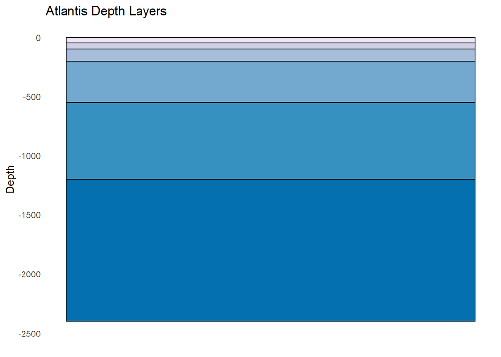

```r
# small function to build enough depth layers for each box, starting with the defined layers above
# in this function, botz is the bottom depth given for each box, which is available in the .bgm file
build_Atlantis_depths <- function(botz,lyrs){
  # bottom of each layer, starting from shallowest
  lyrbot<-cumsum(lyrs)
  # layers to use are all those that are shallower than the given botz
  lyr_vec <- lyrbot[lyrbot>botz]
  # the depth of the deepest layer is equal to botz
  lyr_vec <- c(lyr_vec,botz)
  # in Atlantis, each box has the same number of depth layers, but some layers have zero thickness
  # so we have to pad with zeroes to make all boxes have the same number of layers
  nzeroes <- length(lyrs)-length(lyr_vec)
  lyr_vec <- c(lyr_vec,rep(0,nzeroes))

  # if the Atlantis model has a surface layer, add that here
  # if(surface_layer) lyr_vec[length(lyr_vec)] <- surface_layer_botz
  # this returns a vector the BOTTOM-most depth of each layer, starting with the shallowest layer
  lyr_vec
}
# construct the depth profiles of each Atlantis box

atlantis_depths <- atlantis_bgm$boxes %>% select(.bx0,botz) %>%
  # apply the function above to create the layers
  mutate(maxz=purrr::map(botz,~build_Atlantis_depths(.,lyrs=atlantis_z))) %>%
  unnest(cols=c(maxz)) %>%
  # add a minimum depth for each layer
  group_by(.bx0) %>%
  mutate(minz=lag(maxz,1,default = 0),atlantis_layer=1:length(atlantis_z)) %>%
  # add a layer thickness calculation
  mutate(dz=minz-maxz) %>%
  # "dummy" layers (layers too deep for a given Atlantis box) should have minz and dz=0
  mutate(minz=ifelse(maxz==0,0,minz),dz=ifelse(maxz==0,0,dz)) %>%
  # NOTE: 03/22/21 OWEN IS REMOVING THE SEDIMENT LAYER FOR NOW BECAUSE IT GETS ADDED LATER
  # group_by(.bx0) %>%
  # mutate(dz=c(dz[1:(length(dz)-1)],1)) %>%
  # ungroup() %>%
  # filter out all the zero-thickness layers and clean up
  # filter(dz!=0) %>%
  select(.bx0,atlantis_layer,minz,maxz,dz)

# face depths (for later flux calcs)

face_depths <- faces %>%
  left_join(atlantis_depths %>% select(.bx0,atlantis_layer,dz),by=c("left"=".bx0")) %>%
  mutate(left_area=length*dz) %>%
  select(-dz) %>%
  left_join(atlantis_depths %>% select(.bx0,atlantis_layer,dz),by=c("right"=".bx0","atlantis_layer")) %>%
  mutate(right_area=length*dz) %>%
  select(-dz) %>%
  # area of the face is the average area, maintaining NAs (if one box is deeper than its neighbor, no flux)
  rowwise() %>%
  mutate(face_area=ifelse((left_area>0 & right_area >0), min(left_area, right_area), NA)) # I think this should be the area of the smaller face instead of the average of the two? Imagine a box to have 6 layers, and its neighboring box only 2 (e.g. along a steep depth gradient). The 4 layers starting from the bottom of the deep box (layers 3-6) do not communicate with the adjacent shallow box because layers 3-6 do not exists in the shallow box. In other words, mean(area_of_face_at_layer_6_in_deep_box, 0) = area_of_face_6_in_deep_box/2, which makes no sense for the shallow box since layer 6 does not exist there. Also if there is no contact bertween two faces at a certain depth (i.e. one of the areas is 0), area in common is NA. Else, there will be vertical fluxes for depth layers that do not exist.

# | box1  ||  box2  | # layer 1: same face surface for box1 and box2 (surface = min(surface1, surface2))
# '-------'|        | # layer 2: face surface of box2 is larger (i.e. deeper), but both boxes have face surface at this depth (surface = min(surface1, surface2))
#          |        | # layers 3-6: only box2 has these layers, so there is no face surface in common between the two boxes (surface = NA)
#          |        |
#          |        |
#          |________|
```

Alternatively, the depth layers can be pulled directly from the initial conditions file for Atlantis (if this has already been build). You don’t need to do this if you’ve added your own manual Atlantis depth vector in the previous step.

```r
initnc <- tidync(here('data','atlantis','DIVCalCurrentV3_Biol.nc'))
init_vars <- hyper_grids(initnc) %>% # all available grids in the ROMS ncdf
  pluck("grid") %>% # for each grid, pull out all the variables asssociated with that grid and make a reference table
  purrr::map_df(function(x){
    initnc %>% activate(x) %>% hyper_vars() %>%
      mutate(grd=x)
  })
atlantis_depths2 <- initnc %>% activate(init_vars %>% filter(name=="nominal_dz") %>% pluck('grd')) %>% hyper_tibble()
```

## ROMS Depths

Now, find and convert ROMS depths. Useful images [here](https://www.myroms.org/wiki/File:vertical_grid.png) and [here](https://www.myroms.org/wiki/Numerical_Solution_Technique#Vertical_Discretization)

Depth at $\rho$ points is stored in the $h$ variable, and we can use that to calculate the “real” depth of ROMS layers.

```r
# convert ROMS s-coordinates to depth with Mike Sumner's angstroms package
library(angstroms)
# read in ROMS from west coast

romsdepths <- romshcoords(romsfile, S = "Cs_r", depth = "h")
```

```
## [1] "vobjtovarid4: **** WARNING **** I was asked to get a varid for dimension named xi_rho BUT this dimension HAS NO DIMVAR! Code will probably fail at this point"
## [1] "vobjtovarid4: **** WARNING **** I was asked to get a varid for dimension named eta_rho BUT this dimension HAS NO DIMVAR! Code will probably fail at this point"
```

```r
romsdepths <- subset(romsdepths, dim(romsdepths)[3]:1) # angstroms returns depths from shallowest to deepest, while below we extract ROMS variables from deepest to shallowest. flipping here or else it maps ROMS variables upside-down

# view
# this_layer <- 20 # pick one between 1:42
# plot(depths[[this_layer]])
# done
# using tabularaster to convert to tibble
# and a indexing template with "by_column" filling
romsi <- crossing(xi_rho=1:dim(romsdepths)[2],eta_rho=1:dim(romsdepths)[1]) %>% arrange(-eta_rho) %>% mutate(cellindex=row_number()) # making sure that the join by cellindex below is correct - doing this for consistency with the way tabularaster::as_tibble() unpacks the raster cells
romsdepthsdf <- tabularaster::as_tibble(romsdepths,dim=F) %>%
  arrange(cellindex) %>%
  left_join(romsi,by='cellindex') %>%
  set_names(c("romsdepth","cellindex","xi_rho","eta_rho")) %>%
  group_by(cellindex,xi_rho,eta_rho) %>%
  nest(romsdepth=c(romsdepth)) %>% ungroup() %>%
  mutate(romsdepth=purrr::map(romsdepth,function(x)x[['romsdepth']]))
```

Remember that, for ROMS:

- $\rho$ has $(\xi,\eta)$ dimensions 186 and 181, respectively
- $u$ has $(\xi,\eta)$ dimensions 185 and 181, respectively
- $v$ has $(\xi,\eta)$ dimensions 186 and 180, respectively

$u$ and $v$ are assigned the same h as their corresponding $\rho$ points.

NOTE: If ROMS depth is dynamic over time (i.e., $h$, $S$, and $C$ change in each time slice), then the following steps will have to be repeated every “loop” when joining multiple ROMS outputs to the Atlantis grid. If the $x,y$ values of the $\rho$, $u$, and $v$ grids remain unchanged, then everything before this can be calculated only once.

With the matching key, we can join the correct h values to each $\rho$, $u$, and $v$ point

```r
# for rho we just join rho xy data to h
roms_rho_depths <- rhoxy %>%
  left_join(romsdepthsdf,by=c("xi_rho","eta_rho")) %>%
  select(rhoidx,xi_rho,eta_rho,lon_rho,lat_rho,x,y,romsdepth)

roms_u_depths <- uxy %>% # take the coordinate data for u
  # join the matching key
  left_join(romsdepthsdf,by=c('xi_u'='xi_rho','eta_u'='eta_rho')) %>%
  select(uidx,xi_u,eta_u,lon_u,lat_u,x,y,romsdepth)

roms_v_depths <- vxy %>% # take the coordinate data for v
  left_join(romsdepthsdf,by=c('xi_v'='xi_rho','eta_v'='eta_rho')) %>%
  # join the matching key
  select(vidx,xi_v,eta_v,lon_v,lat_v,x,y,romsdepth)
```

## Depth Layer Matching

For flux, we care about the Atlantis polygon faces joined to $u$ and $v$ points. For vertical flux $w$ and for static variables, we care about Atlantis polygons joined to interior $\rho$ points.

To match layers between Atlantis points and ROMS points, we use interval-matching to slot ROMS slices into Atlantis prisms/depth layers. The result of applying the function below is a dataframe that indexes each Atlantis box or face and depth layer; the relevant $\xi$ and $\eta$ values that fall within it (in the case of $\rho$ points) or along it (in the case of $u$ and $v$ values for polygon faces); and the indices of the $\sigma_{\rho}$ vertical vector that belong to each Atlantis layer.

```r
# small function to find the roms depths for a given minimum and maximum atlantis layer depth
# maxz is max depth of an Atlantis layer
# minz is min depth of an Atlantis layer
# romsdepths is a vector of real depths of ROMS

# Albi Mar 4 2021. Changed this to assign ROMS depth to Atlantis z-layer, instead of other way around. This solves incorrect mapping of ROMS depth layers at the boundaries between Atlantis z-layers. Also this assumes that the "top" layer (maxz = 0, minz = 0, dz = 1; number 7 in the California Current example) is sediment. Previous code mapped the shallowest ROMS layer to the sediment layer. Double-check.

find_ROMS_layers <- function(maxz,minz,romsdepths){
  out <- findInterval(vec = c(maxz,minz), x = romsdepths)
  out.idx <- which(out == 1)
  return(out.idx)
  # # these lines deal with edge cases, because we want roms layers to start at 1, not 0
  # # for the max roms layer issue (i.e., the surface) assign the last layer (max roms index value)
  # out[out==0] <- 1
  # out[out==length(romsdepths)+1] <- length(romsdepths)
  # return(seq(out[1],out[2],by=1)) # return a vector of identified ROMS depths layers
}
```

First we use this function to join depths of $\rho$ points to Atlantis boxes/layers.

```r
# join rho depths to boxes index
boxes_rho_fulljoin <- boxes_rho_join %>%
  select(.bx0,botz,area,lon_rho:y) %>%
  st_set_geometry(NULL) %>%
  left_join(roms_rho_depths %>% st_set_geometry(NULL),
  by = c("lon_rho", "lat_rho", "xi_rho", "eta_rho", "rhoidx", "x", "y")) %>%  # join ROMS depth info
  left_join(atlantis_depths,by='.bx0') %>% # join Atlantis depths to expand to all relevant Atlantis layers
  drop_na() %>% # drop empty layers
  mutate(sidx=purrr::pmap(list(maxz,minz,romsdepth),find_ROMS_layers)) %>% #apply layer matching
  # clean up output
  select(.bx0,contains("xi"),contains("eta"),contains("idx"),atlantis_layer,contains("min_"),contains("max_"))
glimpse(boxes_rho_fulljoin)
```

```
## Rows: 62,370
## Columns: 6
## $ .bx0           <dbl> 12, 12, 12, 12, 12, 12, 12, 12, 12, 12, 12, 12, 12, 12,~
## $ xi_rho         <int> 49, 49, 49, 49, 49, 49, 50, 50, 50, 50, 50, 50, 51, 51,~
## $ eta_rho        <int> 167, 167, 167, 167, 167, 167, 167, 167, 167, 167, 167, ~
## $ rhoidx         <int> 30925, 30925, 30925, 30925, 30925, 30925, 30926, 30926,~
## $ sidx           <list> <36, 37, 38, 39, 40, 41, 42>, <33, 34, 35>, <29, 30, 3~
## $ atlantis_layer <int> 1, 2, 3, 4, 5, 6, 1, 2, 3, 4, 5, 6, 1, 2, 3, 4, 5, 6, 1~
```

EDIT: OWEN 04/29/21- Not calculating $w$ values because we will use them to close fluxes

For $w$, the points are at the same lon/lat as $\rho$ points, but there is one more [ROMS layer](https://www.myroms.org/wiki/images/4/41/vertical_grid.png) for $w$, and hence its own vertical coordinate $s_w$ and its own stretching values $Cs_w$

```r
# for w values, we have a different stretching function because there is one more layer
# boxes_w_fulljoin <- boxes_rho_join %>%
#   select(.bx0,botz,area,lon_rho:y) %>%
#   st_set_geometry(NULL) %>%
#   left_join(roms_rho_depths %>% st_set_geometry(NULL),
#             by=c("lon_rho", "lat_rho", "xi_rho", "eta_rho", "rhoidx", "x", "y")) %>%  # join ROMS depth info
#   mutate(romsdepths=map(h,~.*Cs_w)) %>%  # calculate vector of real depths for given h. We use Cs_w instead of Cs_r to convert
#   left_join(atlantis_depths_rev,by='.bx0') %>% # join Atlantis depths to expand to all relevant Atlantis layers
#   drop_na() %>% # drop empty layers
#   mutate(sidx=purrr::pmap(list(maxz,minz,romsdepths),find_ROMS_layers)) %>% #apply layer matching
#   # clean up output
#   select(.bx0,contains("xi"),contains("eta"),contains("idx"),atlantis_layer,contains("min_"),contains("max_"))
# glimpse(boxes_w_fulljoin)
```

Finally, for $u$ and $v$ we care about the points near Atlantis polygon faces, not within boxes. So we use the dataframes created above that match Atlantis polygon faces to $u$ and $v$ points.

```r
# join u depths to boxes index
faces_u_fulljoin <- faces_u_join %>%
  st_set_geometry(NULL) %>%
  left_join(roms_u_depths %>% st_set_geometry(NULL),
            by = c("lon_u", "lat_u", "xi_u", "eta_u", "uidx", "x", "y")) %>%  # join ROMS depth info
  left_join(boxes_u_join,by='uidx') %>% # use the boxes/u-values key to match u points to Atlantis boxes
  left_join(atlantis_depths,by='.bx0') %>% # join Atlantis depths to expand to all relevant Atlantis layers
  drop_na() %>% # drop empty layers
  mutate(sidx=purrr::pmap(list(maxz,minz,romsdepth),find_ROMS_layers)) %>% #apply layer matching
  # clean up output
  select(.fx0:length,contains("xi"),contains("eta"),contains("idx"),atlantis_layer,contains("min_"),contains("max_"))
glimpse(faces_u_fulljoin)
```

```
## Rows: 27,678
## Columns: 11
## $ .fx0           <dbl> 0, 0, 0, 0, 0, 0, 0, 0, 0, 0, 0, 0, 0, 0, 0, 0, 0, 0, 0~
## $ cosine         <dbl> 0.9962561, 0.9962561, 0.9962561, 0.9962561, 0.9962561, ~
## $ sine           <dbl> 0.08645063, 0.08645063, 0.08645063, 0.08645063, 0.08645~
## $ left           <int> 60, 60, 60, 60, 60, 60, 60, 60, 60, 60, 60, 60, 60, 60,~
## $ right          <int> 59, 59, 59, 59, 59, 59, 59, 59, 59, 59, 59, 59, 59, 59,~
## $ length         <dbl> 37982.78, 37982.78, 37982.78, 37982.78, 37982.78, 37982~
## $ xi_u           <int> 154, 154, 154, 154, 154, 154, 155, 155, 155, 155, 155, ~
## $ eta_u          <int> 36, 36, 36, 36, 36, 36, 36, 36, 36, 36, 36, 36, 37, 37,~
## $ uidx           <int> 6629, 6629, 6629, 6629, 6629, 6629, 6630, 6630, 6630, 6~
## $ sidx           <list> <28, 29, 30, 31, 32, 33, 34, 35, 36, 37, 38, 39, 40, 4~
## $ atlantis_layer <int> 1, 2, 3, 4, 5, 6, 1, 2, 3, 4, 5, 6, 1, 2, 3, 4, 5, 6, 1~
```

```r
# join v depths to boxes index
faces_v_fulljoin <- faces_v_join %>%
  st_set_geometry(NULL) %>%
  left_join(roms_v_depths %>% st_set_geometry(NULL),
            by = c("lon_v", "lat_v", "xi_v", "eta_v", "vidx", "x", "y")) %>%  # join ROMS depth info
  left_join(boxes_v_join,by='vidx') %>% # us the boxes/u-values key to match u points to Atlantis boxes
  left_join(atlantis_depths,by='.bx0') %>% # join Atlantis depths to expand to all relevant Atlantis layers
  drop_na() %>% # drop empty layers
  mutate(sidx=purrr::pmap(list(maxz,minz,romsdepth),find_ROMS_layers)) %>% #apply layer matching
  # clean up output
  select(.fx0:right,contains("xi"),contains("eta"),contains("idx"),atlantis_layer,contains("min_"),contains("max_"))
glimpse(faces_v_fulljoin)
```

```
## Rows: 27,618
## Columns: 10
## $ .fx0           <dbl> 0, 0, 0, 0, 0, 0, 0, 0, 0, 0, 0, 0, 0, 0, 0, 0, 0, 0, 0~
## $ cosine         <dbl> 0.9962561, 0.9962561, 0.9962561, 0.9962561, 0.9962561, ~
## $ sine           <dbl> 0.08645063, 0.08645063, 0.08645063, 0.08645063, 0.08645~
## $ left           <int> 60, 60, 60, 60, 60, 60, 60, 60, 60, 60, 60, 60, 60, 60,~
## $ right          <int> 59, 59, 59, 59, 59, 59, 59, 59, 59, 59, 59, 59, 59, 59,~
## $ xi_v           <int> 155, 155, 155, 155, 155, 155, 154, 154, 154, 154, 154, ~
## $ eta_v          <int> 35, 35, 35, 35, 35, 35, 36, 36, 36, 36, 36, 36, 36, 36,~
## $ vidx           <int> 6479, 6479, 6479, 6479, 6479, 6479, 6664, 6664, 6664, 6~
## $ sidx           <list> <29, 30, 31, 32, 33, 34, 35, 36, 37, 38, 39, 40, 41, 4~
## $ atlantis_layer <int> 1, 2, 3, 4, 5, 6, 1, 2, 3, 4, 5, 6, 1, 2, 3, 4, 5, 6, 1~
```

# Pull Static Variables

```r
# function to pull ROMS data
# for now, this should work with things like salt, temp, u, v, w
# returns an array with all of the data from the one time-slice of ROMS
pull_var <- function(variable){
  grd <- roms_vars %>% filter(name==variable) %>% pluck('grd')
  dat <- roms %>% activate(grd) %>%
    #hyper_filter(ocean_time = index == time_step) %>% # something like this to filter time steps. It would need time_step to be an argument of this function, and then to make a function below t pull ther static variables from one step at a time. See Albi's code for Ecopath stuff.
    hyper_array()
  return(dat[[variable]])
}
# index into the variable array using xi, eta, and s indices
join_var <- function(a,xi,eta,s) a[xi,eta,s]
```

Static Variables

```r
salt <- pull_var('salt')
temperature <- pull_var('temp')
boxes_roms_salt_temp <- boxes_rho_fulljoin %>%
  mutate(salt_vec=pmap(list(xi_rho,eta_rho,sidx),join_var,a=salt),
         temp_vec=pmap(list(xi_rho,eta_rho,sidx),join_var,a=temperature))
glimpse(boxes_roms_salt_temp)
```

```
## Rows: 62,370
## Columns: 8
## $ .bx0           <dbl> 12, 12, 12, 12, 12, 12, 12, 12, 12, 12, 12, 12, 12, 12,~
## $ xi_rho         <int> 49, 49, 49, 49, 49, 49, 50, 50, 50, 50, 50, 50, 51, 51,~
## $ eta_rho        <int> 167, 167, 167, 167, 167, 167, 167, 167, 167, 167, 167, ~
## $ rhoidx         <int> 30925, 30925, 30925, 30925, 30925, 30925, 30926, 30926,~
## $ sidx           <list> <36, 37, 38, 39, 40, 41, 42>, <33, 34, 35>, <29, 30, 3~
## $ atlantis_layer <int> 1, 2, 3, 4, 5, 6, 1, 2, 3, 4, 5, 6, 1, 2, 3, 4, 5, 6, 1~
## $ salt_vec       <list> <32.59223, 32.55443, 32.53950, 32.53510, 32.53363, 32.~
## $ temp_vec       <list> <9.079984, 9.198164, 9.271120, 9.293169, 9.296890, 9.2~
```

If we want, we can calculate some summary function for these values here. For example, we could calculate, for each polygon and Atlantis layer, the mean salinity and temperature.

```r
boxes_roms_salt_temp <- boxes_roms_salt_temp %>%
  mutate(meansalt_rho=map_dbl(salt_vec,mean,na.rm=T),
         meantemp_rho=map_dbl(temp_vec,mean,na.rm=T)) %>%
  filter(!is.nan(meansalt_rho),!is.nan(meantemp_rho)) %>%
  group_by(.bx0,atlantis_layer) %>%
  summarise(meansalt=mean(meansalt_rho, na.rm = T),
            meantemp=mean(meantemp_rho, na.rm = T)) %>% # check this, but some rho points have NA values for salt and temp, which then carry over to the entire box when averaging if we do not remove them
  ungroup()
```

Map of surface salinity for this time slice. Gray boxes are outside ROMS domain and hence did not match to $\rho$ points

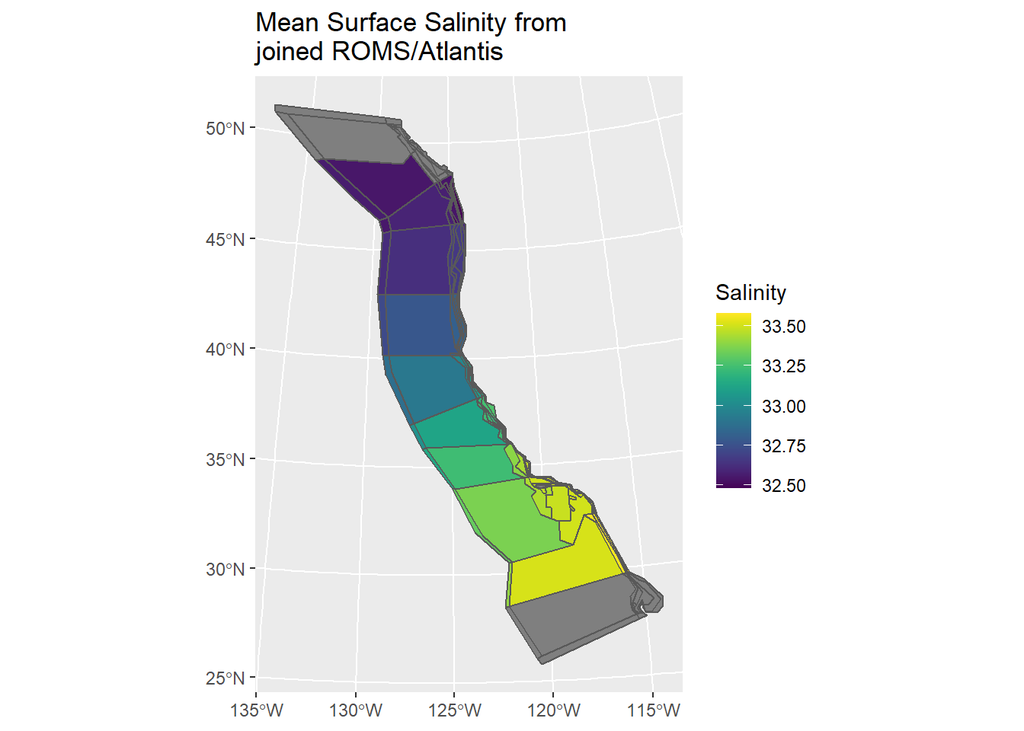

```r
boxes_roms_salt_temp %>%
  #filter(atlantis_layer!=7) %>%
  group_by(.bx0) %>%
  slice_min(atlantis_layer) %>%
  ungroup() %>%
  full_join(atlantis_sf,by='.bx0') %>%
  st_as_sf() %>%
  ggplot(aes(fill=meansalt))+
  geom_sf()+
  scale_fill_viridis()+
  labs(fill="Salinity",title="Mean Surface Salinity from\njoined ROMS/Atlantis")
```

# Calculate Fluxes

Apply the functions above to pull vectors of ROMS data into the joined dataframes.

```r
u <- pull_var('u')
faces_roms_u<- faces_u_fulljoin %>%
  mutate(uvec=pmap(list(xi_u,eta_u,sidx),join_var,a=u)) # pull u values from ROMS
glimpse(faces_roms_u)
```

```
## Rows: 27,678
## Columns: 12
## $ .fx0           <dbl> 0, 0, 0, 0, 0, 0, 0, 0, 0, 0, 0, 0, 0, 0, 0, 0, 0, 0, 0~
## $ cosine         <dbl> 0.9962561, 0.9962561, 0.9962561, 0.9962561, 0.9962561, ~
## $ sine           <dbl> 0.08645063, 0.08645063, 0.08645063, 0.08645063, 0.08645~
## $ left           <int> 60, 60, 60, 60, 60, 60, 60, 60, 60, 60, 60, 60, 60, 60,~
## $ right          <int> 59, 59, 59, 59, 59, 59, 59, 59, 59, 59, 59, 59, 59, 59,~
## $ length         <dbl> 37982.78, 37982.78, 37982.78, 37982.78, 37982.78, 37982~
## $ xi_u           <int> 154, 154, 154, 154, 154, 154, 155, 155, 155, 155, 155, ~
## $ eta_u          <int> 36, 36, 36, 36, 36, 36, 36, 36, 36, 36, 36, 36, 37, 37,~
## $ uidx           <int> 6629, 6629, 6629, 6629, 6629, 6629, 6630, 6630, 6630, 6~
## $ sidx           <list> <28, 29, 30, 31, 32, 33, 34, 35, 36, 37, 38, 39, 40, 4~
## $ atlantis_layer <int> 1, 2, 3, 4, 5, 6, 1, 2, 3, 4, 5, 6, 1, 2, 3, 4, 5, 6, 1~
## $ uvec           <list> <0.015714549, 0.016721925, 0.016812852, 0.014674025, 0~
```

```r
v <- pull_var('v')

faces_roms_v<- faces_v_fulljoin %>%
  mutate(vvec=pmap(list(xi_v,eta_v,sidx),join_var,a=v)) # pull v values from ROMS
glimpse(faces_roms_v)
```

```
## Rows: 27,618
## Columns: 11
## $ .fx0           <dbl> 0, 0, 0, 0, 0, 0, 0, 0, 0, 0, 0, 0, 0, 0, 0, 0, 0, 0, 0~
## $ cosine         <dbl> 0.9962561, 0.9962561, 0.9962561, 0.9962561, 0.9962561, ~
## $ sine           <dbl> 0.08645063, 0.08645063, 0.08645063, 0.08645063, 0.08645~
## $ left           <int> 60, 60, 60, 60, 60, 60, 60, 60, 60, 60, 60, 60, 60, 60,~
## $ right          <int> 59, 59, 59, 59, 59, 59, 59, 59, 59, 59, 59, 59, 59, 59,~
## $ xi_v           <int> 155, 155, 155, 155, 155, 155, 154, 154, 154, 154, 154, ~
## $ eta_v          <int> 35, 35, 35, 35, 35, 35, 36, 36, 36, 36, 36, 36, 36, 36,~
## $ vidx           <int> 6479, 6479, 6479, 6479, 6479, 6479, 6664, 6664, 6664, 6~
## $ sidx           <list> <29, 30, 31, 32, 33, 34, 35, 36, 37, 38, 39, 40, 41, 4~
## $ atlantis_layer <int> 1, 2, 3, 4, 5, 6, 1, 2, 3, 4, 5, 6, 1, 2, 3, 4, 5, 6, 1~
## $ vvec           <list> <-0.009122122, -0.006446036, -0.005312658, -0.00584071~
```

```r
# as of March 2021 we are not pulling w out of ROMS, instead we're using it to close fluxes
# w <- pull_var('w')
# boxes_roms_w <- boxes_w_fulljoin %>%
#   mutate(wvec=pmap(list(xi_rho,eta_rho,sidx),join_var,a=w))
# glimpse(boxes_roms_w)
```

Do some trigonometry (yikes!) to calculate actual vectors of flow across each face.

```r
# test_u <- faces_roms_u %>%
#   # join area of each face (averaged between that layer of left and right-side boxes)
#   left_join(face_depths_rev) %>%
#   # calculate angle perpendicular to face (pointing left to right)
#   # angles of the faces are in the 1st and 3rd quadrants (pos cos and pos sin or neg cos and neg sin)
#   mutate(angle=atan2(ifelse(sine>0,-sine,sine),ifelse(cosine>0,cosine,-cosine))) %>%
#   # take mean v and u
#   group_by(.fx0,length,atlantis_layer,face_area,angle,xi_u,eta_u) %>%
#   mutate(meanu=map_dbl(uvec,mean)) %>%
#   group_by(.fx0,length,atlantis_layer,face_area,angle) %>%
#   summarise(meanu=mean(meanu)) %>%
#   ungroup()
#
# test_v <- faces_roms_v %>%
#   # join area of each face (averaged between that layer of left and right-side boxes)
#   left_join(face_depths_rev) %>%
#   # calculate angle perpendicular to face (pointing left to right)
#   # angles of the faces are in the 1st and 3rd quadrants (pos cos and pos sin or neg cos and neg sin)
#   mutate(angle=atan2(ifelse(sine>0,-sine,sine),ifelse(cosine>0,cosine,-cosine))) %>%
#   # take mean v and u
#   group_by(.fx0,length,atlantis_layer,face_area,angle,xi_v,eta_v) %>%
#   mutate(meanv=map_dbl(vvec,mean)) %>%
#   group_by(.fx0,length,atlantis_layer,face_area,angle) %>%
#   summarise(meanv=mean(meanv)) %>%
#   ungroup()
# test_uv <- test_u %>% left_join(test_v) %>%
#   mutate(uv_angle=atan(meanv/meanu),uv_mag=sqrt(meanu^2+meanv^2)) %>%
#   mutate(angle_diff=angle-uv_angle,
#          new_vec=uv_mag*cos(angle_diff))
```

## Albi’s alternative approach for calculating fluxes.

The premise: I cannot seem to understand how sine and cosine of the faces are calculated in the BGM file. More specifically I am confused as to why all faces have *either* positive sine **and** positive cosine *or* negative sine **and** negative cosine (sure faces are oriented in all directions in the 2D plane? This pos/pos neg/neg business is the case for a number of BGM files I could get my hands on, but not for all of them); also, I am unsure about the reference axis used to calculate the angle defined by the faces according to sine and cosine as they are reported in the BGM (that is, it is the angle between the face and what? The North axis? The East axis for consistency with the unit circle? In many examples of BGM files retrieved from bgmfiles::bgmfiles() neither of these seems to be the case). I tried to get in touch with who wrote the BGMeriser package through a CSIRO contact to see if I can understand it from the source code, but I am still waiting for an answer.

So, I calculate the angles of the faces myself from topological information in the BGM.

1. For a face between p1 and p2 (where p1(x1,y1) and p2(x2,y2)) I calculate the angle $\alpha$ of the face not from sine and cosine as they appear in the BGM file, but with atan2(y2-y1, x2-x1). I have done a fair bit of testing and this seems to work. Angles of the faces here are expressed in polar coordinates where E=0, N=90, and S=-90. That is, I am keeping the sign of the angles without normalizing to +360 (or +2$\pi$), because the sign will become important later to work out the direction of a flux across a face.
2. If for each ROMS cell u and v denote the eastward and northward components of a flux respectively, I calculate the angle $\beta$ of the resulting uv flux as atan2(v,u). $\beta$ also is returned in polar coordinates: positive values (in radians) place it in the 1st and 2nd quadrants, negative values (in radians) in the 3rd and 4th. Again done a good bit of testing and this seems to check out.
3. To calculate the angle $\gamma$ of the flux relative to each face, I subtract the face angle from the flux angle ($\gamma$ = $\beta$ - $\alpha$).
4. To have $\gamma$ positive when it points to the left and negative when it points to the right of the face (when looking from p1 to p2), I modify $\gamma$ in the following way (this does not change the angle as I add or subtract $2\pi$):
- If $0\le\gamma\le\pi$ or $-\pi\le\gamma <0$, leave it as it is.
- If $\gamma<-\pi$, then $\gamma = \gamma+2\pi$.
- If $\gamma>\pi$, then $\gamma=\gamma-2\pi$.
5. Based on the value of $\gamma$, I assign a scalar to the flux. If $\gamma$>0, +1, if $\gamma$<0, -1. This corresponds to a LR flux being negative, and a RL flux positive, which is the convention for the Hydroconstruct (and Atlantis) files.

```r
# from the faces_sf spatial object, let's retrieve geometry information of the points that define each face, and calculate the angle. Also calclate its sine and cosine to see how they compare with the BGM values

get_angle <- function(geomstring) {
  coords <- st_coordinates(geomstring)
  this_atan <- atan2(coords[2,2]-coords[1,2], coords[2,1]-coords[1,1]) # as per R help, atan2(y,x)
  return(this_atan)
}

faces_sf_albi <- faces_sf %>% rowwise() %>% mutate(face_angle = get_angle(geometry),
                                                   sine_albi = sin(face_angle),
                                                   cosine_albi = cos(face_angle)) %>%
  select(.fx0, face_angle) %>% st_set_geometry(NULL) # only keep face id and angle

# now use the same code as above, except the line that works out the angles from sine and cosine

test_u_albi <- faces_roms_u %>%
  # join with angle information for the faces, to be used later for difference between uv and face
  left_join(faces_sf_albi) %>%
  # join area of each face (averaged between that layer of left and right-side boxes)
  left_join(face_depths)%>%
  # take mean u per u point per layer per face
  group_by(.fx0,length,atlantis_layer,face_area,face_angle,xi_u,eta_u) %>%
  mutate(meanu=map_dbl(uvec,mean)) %>%
  # take mean u per layer per face
  group_by(.fx0,length,atlantis_layer,face_area,face_angle) %>%
  summarise(meanu=mean(meanu, na.rm = TRUE)) %>% # doing this for now or NA values for individual points will carry over and turn means into NAs
  ungroup()
test_v_albi <- faces_roms_v %>%
  # join with angle information for the faces, to be used later for difference between uv and face
  left_join(faces_sf_albi) %>%
  # join area of each face (averaged between that layer of left and right-side boxes)
  left_join(face_depths) %>%
  # take mean v per v point per layer per face
  group_by(.fx0,length,atlantis_layer,face_area,face_angle,xi_v,eta_v) %>%
  mutate(meanv=map_dbl(vvec,mean)) %>%
  #take mean v per layer per face
  group_by(.fx0,length,atlantis_layer,face_area,face_angle) %>%
  summarise(meanv=mean(meanv, na.rm = TRUE)) %>% # doing this for now or NA values for individual points will carry over and turn means into NAs
  ungroup()
# pull u and v together.

test_uv_albi <- test_u_albi %>%
  left_join(test_v_albi) %>%
  mutate(uv_angle=atan2(meanv, meanu),uv_mag=sqrt(meanu^2+meanv^2)) %>%
  mutate(diff_angle = uv_angle - face_angle, # beta - alpha
         angle_new = ifelse((diff_angle>=0 & diff_angle<=pi) | (diff_angle<0 & diff_angle>=-pi), diff_angle, # add or subtract 2*pi as needed (9)see above)
                            ifelse(diff_angle < -pi, diff_angle+2*pi, diff_angle-2*pi)),
         orthogonal_flux = uv_mag * sin(angle_new)) # get the component of the flux that is perpendicular to the face. Because of the angle transformation (+/- 2*pi), multiplying by the sine of the angle between uv and the face returns the correct sign for the flux: negative for LR, positive for RL.
```

Results are different from the original version from Owen, so this will need more work / double-checking.

This left and right issue will be the tricky part. After this, it should be only a case of multiplying this flux by area of the face/depth layer to get the net exchange across the face in m3/s, which is what HydroConstruct needs

```r
fluxes <- test_uv_albi %>%
  mutate(gross = orthogonal_flux * face_area) %>%
  select(.fx0, atlantis_layer, gross)
```

## Close Flux Calculations

Using the above-calculated fluxes, “close” the flux budget for each Atlantis box layer, using vertical fluxes.

```r
# Join left and right boxes from bgm
fluxes <- fluxes %>%
  left_join(face_depths %>% select(-sine,-cosine))
# at the moment, there are depth layers of some faces with no gross flux across them. Face 0, for example, is shared by boxes 59 and 60 as deep as layer 5. However, there are no u or v points in the buffer of face 0 that go as deep as layer 5. This kind of inconsistencies will keep happening, and it should be fine as long as we keep an eye on them (e.g., for face 0, what is the flux across layer 5 then? 0 or NA?).

# Summarise fluxes by face and box. Remember that L-R flow is negative, RL flow is positive
# Therefore, we'll use the "left" box of each face to summarise fluxes
box_fluxes_L <- fluxes %>%
  group_by(left,atlantis_layer) %>%
  summarise(totflux_in_from_right=sum(gross,na.rm=T)) %>%
  ungroup() %>%
  rename(box=left)
box_fluxes_R <- fluxes %>%
  group_by(right,atlantis_layer) %>%
  # for the right side, use the opposite of the gross flux
  # because we want positive in this case to be L-R
  summarise(totflux_in_from_left=-sum(gross,na.rm=T)) %>%
  ungroup() %>%
  rename(box=right)
```

The bit below is just to help Albi visualise things - and for future reference.

1. Atlantis convention: across each face, a flux LR is always negative, and a RL flux always positive.
2. Considering a focal box $b$, it makes sense to think of a flux going out of the box as negative (i.e. a loss of water from $b$), and a flux coming into the box as positive (i.e. a gain in water in $b$).
3. How do we couple 1 and 2? It would work okay if the focal box was always to the left of the faces that sorround it, or in other words if the orientation of the faces was always counterclockwise. This is not the case, probably because adjacent boxes share the same faces, and a face can have either one or the other box to its left, not both (remember, a face has a fixed orientation from p1 to p2, so right and left are always the same for a given face).
4. Let’s focus on $b$. Let’s find all the faces that delimit $b$. For all these faces, we know what boxes are to their left and to their right, from the BGM. So, for faces that have $b$ to their left, a LR flux across a face is indeed a loss of water from $b$. For faces that have $b$ to their right, instead, a LR flux across the face (which is always negative by convention) actually represents water moving into $b$. So as far as $b$ is concerned, that flux is, in fact, positive, and its sign needs to be changed.

```r
set.seed(425)
focal_box <- sample(fluxes$left,1)

testL <- fluxes %>% filter(left == focal_box) %>% mutate(color = "focal_box_to_left")
testR <- fluxes %>% filter(right == focal_box) %>% mutate(color = "focal_box_to_right")

face_colors <- rbind((testL %>% select(.fx0, color)), (testR %>% select(.fx0, color))) %>% distinct()
focal_faces <- faces_sf %>% inner_join(face_colors)
```

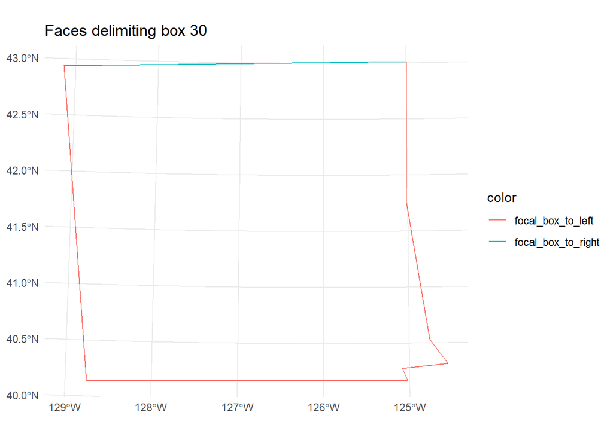

```r
ggplot()+
  geom_sf(data = focal_faces, aes(color = color))+
  theme_minimal()+
  labs(title=paste("Faces delimiting box", focal_box, sep = " "))
```

Some boxes are open, they might be the ones at the edges of the ROMS domain and have no $u$ and $v$ points around them.

Now, join the fluxes together, and find the net flow. Close the budget by introducing downwelling or upwelling:

- If flow is converging (net positive change in flow in the surface Atlantis box), introduce vertical flux downward in to the next layer
- If flow is diverging (net negative change in flow in the surface Atlantis box), introduce vertical flux upwards from the next layer.

Upwelling and downwelling represent $w$. The input to HydroConstruct seems to need $w$ expressed as some variation of the following language (from NETCDF type input in Hawaii and SEAP, respectively):

float verticalflux(time, boxes, level) ;  
verticalflux:units = “m3/s” ;  
verticalflux:_FillValue = -999.f ;  
verticalflux:long_name = "vertical velocity averaged over volume (velocity*area)" ;  
verticalflux:positive = “upwards” ;  
float verticalflux(time, boxes, level) ;  
verticalflux:long_name = “vertical flux averaged over floor of box” ;  
verticalflux:positive = “upwards” ;  
verticalflux:units = “m/s” ;  
verticalflux:_FillValue = -1.e+21f ;

So it sounds like producing the net flux should be the right thing to do, and the units are the same as our fluxes. Albi to check whether HydroConstruct turns this into m3/time step (i.e. flux m3/sec * 43200 sec), or if we need to do it before HydroConstruct. Also worth noting that the input for HydroConstruct from Puget Sound and California Current (DAT files, input_type = 9) list values of vertical velocity in [10^-6*m/s]. Can check with Isaac, does m/s mean m3/s or is it flux by unit area [m3/s/m2]?

**HydroConstruct seems to consider upward fluxes as positive.**

```r
box_fluxes <- box_fluxes_L %>%
  full_join(box_fluxes_R,by=c('box','atlantis_layer')) %>%
  # net flow
  rowwise() %>%
  mutate(net_flux=ifelse((totflux_in_from_right == 0 & totflux_in_from_left == 0),NA,sum(totflux_in_from_right,totflux_in_from_left))) %>% # if all fluxes are 0, it means that the current layer does not exist for that box, so set the flux to NA
  # hmm, trying to figure out how to do this next step
  group_by(box) %>%
  # net upwelling in m3/s - minus sign because HydroConstruct needs positive up
  mutate(w=-cumsum(net_flux)) %>%
  ungroup() %>%
  select(-totflux_in_from_right, -totflux_in_from_left) %>%
  left_join(select(atlantis_sf, .bx0, area), by = c("box" = ".bx0"))
```

We can plot this to visualise.

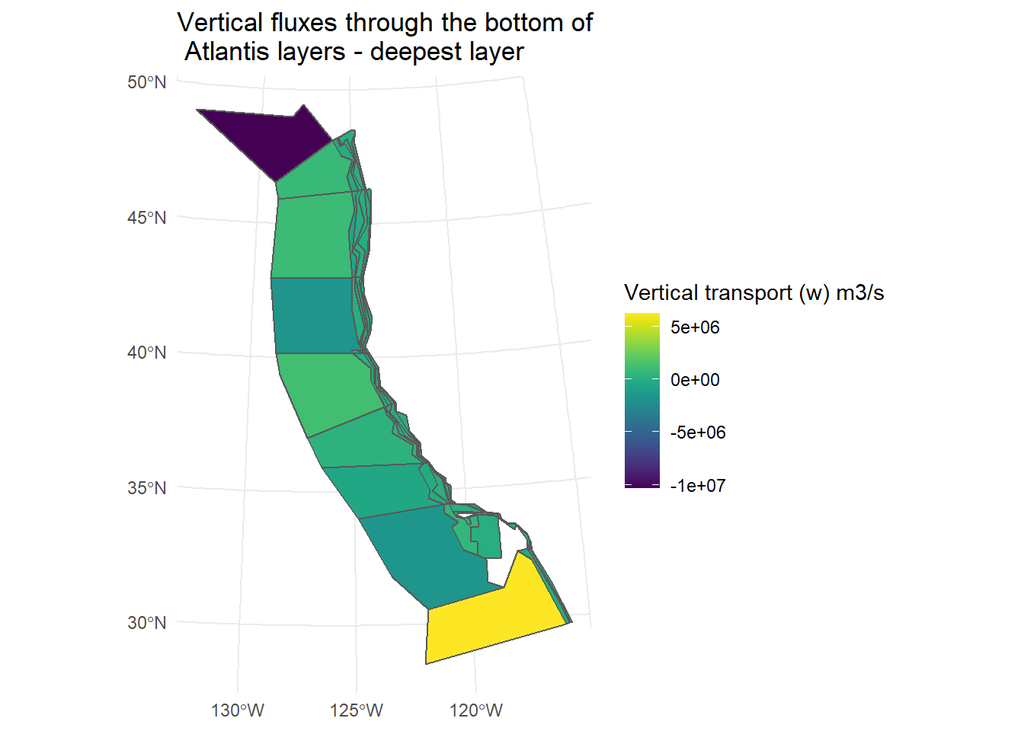

```r
box_fluxes  %>%
  st_as_sf(sf_column_name = "geometry") %>%
  na.omit() %>%
  group_by(box) %>%
  slice_max(atlantis_layer) %>%
  ggplot()+
  geom_sf(aes(fill = w))+
  scale_fill_viridis()+
  theme_minimal()+
  labs(fill="Vertical transport (w) m3/s",title="Vertical fluxes through the bottom of \n Atlantis layers - deepest layer")
```

Hard to tell what is sensible here.

As it stands, we have the issue of closing the budget of the bottom layer for each box. That is, our method allows for water flowing through the bottom of the bottom layer. Options for what we can do about that:

1. Nothing - take the “sure it will go away over a few time steps” approach and see if the model implodes before doing anything else.
2. Use box 0 to “balance” these fluxes. See discussion [here](https://confluence.csiro.au/display/Atlantis/Hydro+FAQ). Also see the User Guide: *“Box 0 is special because it is set up to have water and nutrient fluxes to nearly all other model boxes. This is set to simulate supply of advective tracers to the oceanic boxes and accommodate any missing water fluxes due to conversion of oceanographic files into Atlantis input files (see chapter 4). While the model is running it also acts as a store for information on any migrating groups currently outside the model domain.”*

Box 0 is outside the ROMS domain for CalCurrent for now, so let’s put this off.

## Correction for hyperdiffusion

The current workflow does not account for the correction for hyperdiffusion that happens when running Hydroconstruct.

For now, let’s apply a coarse correction for hyperdiffusion in the form of flux/area (i.e. type 1 correction in HydroConstruct), and recalculate $w$ accounting for that.

```r
box_fluxes <- box_fluxes %>%
  group_by(box) %>%
  mutate(hyperdiff_corrected = net_flux/area,
         w_corrected = -cumsum(hyperdiff_corrected))
```

Visualise.

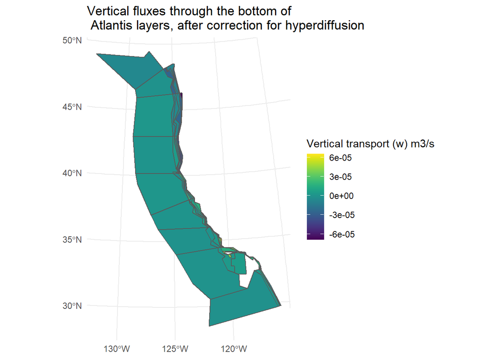

```r
box_fluxes %>%
  st_as_sf(sf_column_name = "geometry") %>%
  na.omit()%>%
  slice_min(atlantis_layer) %>%
  ggplot()+
  geom_sf(aes(fill = w_corrected))+
  scale_fill_viridis()+
  theme_minimal()+
  labs(fill="Vertical transport (w) m3/s",title="Vertical fluxes through the bottom of \n Atlantis layers, after correction for hyperdiffusion")
```